# Predicting Systemic Crises in African Economies

Names: Said Arslan, Declan Gray-Mullen, and Rakeen Tanvir

Due Date: December 15, 2021, 5:59pm

# 1 Data collection and preparation

## 1.1 Import and transform into tidy data

```r
(ac <-
   read_csv("reference/african_crises.csv",
    col_types = cols(
        case = col_integer(),
        cc3 = col_factor(ordered = TRUE),
        country = col_character(),

        year = col_date(format = "%Y"),

        exch_usd = col_double(),
        gdp_weighted_default = col_double(),
        inflation_annual_cpi = col_double(),

        systemic_crisis = col_logical(),
        domestic_debt_in_default = col_logical(),
        sovereign_external_debt_default = col_logical(),
        independence = col_logical(),
        currency_crises = col_integer(),
        inflation_crises = col_logical(),

        banking_crisis = col_character()
    )
  )
  %>% mutate(banking_crisis = (banking_crisis == "crisis"))
  %>% mutate(currency_crises = (currency_crises > 0)) # assume 2==1 in 4 cases
)
```

```
## # A tibble: 1,059 × 14
##     case cc3   country year       systemic_crisis exch_usd domestic_debt_in_def…
##    <int> <fct> <chr>   <date>     <lgl>              <dbl> <lgl>
##  1     1 DZA   Algeria 1870-01-01 TRUE              0.0523 FALSE
##  2     1 DZA   Algeria 1871-01-01 FALSE             0.0528 FALSE
##  3     1 DZA   Algeria 1872-01-01 FALSE             0.0523 FALSE
##  4     1 DZA   Algeria 1873-01-01 FALSE             0.0517 FALSE
##  5     1 DZA   Algeria 1874-01-01 FALSE             0.0513 FALSE
##  6     1 DZA   Algeria 1875-01-01 FALSE             0.0515 FALSE
##  7     1 DZA   Algeria 1876-01-01 FALSE             0.0519 FALSE
##  8     1 DZA   Algeria 1877-01-01 FALSE             0.0519 FALSE
##  9     1 DZA   Algeria 1878-01-01 FALSE             0.0519 FALSE
## 10     1 DZA   Algeria 1879-01-01 FALSE             0.0520 FALSE
## # … with 1,049 more rows, and 7 more variables:
## #   sovereign_external_debt_default <lgl>, gdp_weighted_default <dbl>,
## #   inflation_annual_cpi <dbl>, independence <lgl>, currency_crises <lgl>,
## #   inflation_crises <lgl>, banking_crisis <lgl>
```

```r
assertthat::noNA(ac)
```

```
## [1] TRUE
```

The data is tidy: Each variable has its own column, each observation has its own row, and each value has its own cell.

## 1.2 The variables in `ac`

1. `case` is a integer variable that identifies the index for each country from the original, global dataset.
2. `cc3` is a factor variable that identifies each country with a three letter code.
3. `country` is a character variable that names each country.
4. `year` is a date variable that identifies the year of the observation.
5. `systemic_crisis` is a logical indicator variable that indicates the occurrence of a systemic crisis: significant signs of financial distress in a majority of the banking system coupled with signficant banking policy intervention measures implemented by financial authorities in response.
6. `exch_usd` is a double variable expressing the exchange rate of USD to the associated country’s currency.
7. `domestic_debt_in_default` is a logical indicator variable that indicates the occurrence of a failure of government in repyament of its domestic debts owed to domestic residents of the country.
8. `sovereign_external_debt_default` is a logical indicator variable that indicates the occurrence of a failure of government to honor some or all of its debt obligations to the external lenders.
9. `gdp_weighted_default` is a double variable in the data but its meaning is unclear.
10. `inflation_annual_cpi` is a double variable that expresses the percent change in the consumer price index, generally used as a measure of inflation.
11. `independence`
12. `currency_crises` is a logical indicator variable that indicates the occurrence of serious doubt as to whether a country’s central bank has sufficient foreign exchange reserves to maintain the country’s fixed exchange rate.
13. `inflation_crises` is a logical indicator variable that indicates the occurrence of an inflation crisis which means very high and typically accelerating inflation.
14. `banking_crisis` is a logical indicator variable that indicates whether a banking crisis (demise of a financial institution) occurred.

## 1.3 Web Scraping: Commodity Import & Export Price Index

*Commodity of Terms of Trade: Commodity Import/Export Price Index, Individual Commodites Weighted by Ratio of Imports to GDP Historical, Annual (1965-present), Fixed Weights, Index (2012=100)*

In order to expand the features of our dataset, we scrape additional data provided by the International Monetary Fund (IMF). While the IMF provides many formats including API REST endpoints, excel and csv file formats but we instead scrape the rendered html using their [online table viewer](https://data.imf.org/?sk=2CDDCCB8-0B59-43E9-B6A0-59210D5605D2&sId=1390030341854).

Using the viewer we selected the desired data and used inspect in Chrome to view the rendered html for the current page. We copied the div representing the entire table in html and pasted the text into local files.

First we wrote a function to convert the html, into a df matching the table viewer online.

```r
imf_html_to_df = function (html_filename){

  # we get the column labels by looking at the custom filename
  filename_pieces = str_split(html_filename, "_")[[1]]

  # read all the html in the file
  html_str = readLines(html_filename)

  # function returning the elements matched by the regex
  html_to_byRowList = function(full_file_str){
    regex_exp = "<div class=\"PPTSCellConText.*?>(.*?)<"
    result = stringr::str_match_all(full_file_str, regex_exp)
    return(result[[1]][, 2])
  }

  # all elements in our df by row
  elements = html_to_byRowList(html_str)

  # df 'schema' defined
  columns = c("country", seq(as.integer(filename_pieces[3]), as.integer(filename_pieces[4]), by=1))
  num_columns = length(columns)
  schema = matrix(ncol = num_columns, nrow = 0)
  df = data.frame(schema)
  colnames(df) = columns

  # grab 'inflation' elements, ignoring column headers
  elements = elements[num_columns:length(elements)]

  # populate df iterating through element by df row
  start = 1
  while(start + num_columns - 1 <= length(elements)){
    curr = elements[start:(start+num_columns-1)]
    curr = do.call(c, list(list(curr[1]), as.double(curr[2:(length(curr))])))
    df[nrow(df) + 1,] = curr
    start = start + num_columns
  }

  # add cc3 labels used in joining later
  df$cc3 = as_factor(countrycode(df$country, origin = 'country.name', destination = 'iso3c'))
  return(df)
}
```

We then used that function to generate df’s for each 20 year grouping and join them together final IMF df (since at most 20 columns render)!

```r
export_df = merge(x=merge(x=export_df_1, y=export_df_2, by=c("cc3", "country")), y=export_df_3, by=c("cc3", "country"))
as_tibble(export_df)
```

```
## # A tibble: 13 × 58
##    cc3   country  `1965` `1966` `1967` `1968` `1969` `1970` `1971` `1972` `1973`
##    <fct> <chr>     <dbl>  <dbl>  <dbl>  <dbl>  <dbl>  <dbl>  <dbl>  <dbl>  <dbl>
##  1 AGO   Angola     40.8   40.4   40.4   40.6   40.4   39.6   40.9   40.8   40.9
##  2 CAF   Central…   99.9   99.9  100.   100.    99.7  100.    99.6   99.4  100.
##  3 CIV   Côte d'…   92.8   94.7   95.4   96.7   98.1   95.8   92.5   93.0   98.0
##  4 DZA   Algeria    59.2   58.8   59.0   59.1   58.9   58.1   58.6   58.6   58.9
##  5 EGY   Egypt      94     93.9   94.0   94.0   94.0   93.8   93.9   93.9   94.1
##  6 KEN   Kenya     100.   100.   100.    99.7   99.6   99.8   99.4   99.4   99.4
##  7 MAR   Morocco   101.   100.   101.   101.   101.   101.   100.   101.   102.
##  8 MUS   Mauriti…   97.2   95.6   95.7   95.5  100.   101.   101    105.   108.
##  9 NGA   Nigeria    66.8   66.5   66.5   66.6   66.5   65.9   66.7   66.7   66.9
## 10 TUN   Tunisia    90.6   90.5   90.5   90.6   90.6   90.3   90.6   90.6   90.9
## 11 ZAF   South A…   96.8   96.6   96.5   96.6   96.8   96.9   96.6   96.6   96.9
## 12 ZMB   Zambia     98.5  102.    94.7   96.8   99.7   97.8   89.5   88.0   96.4
## 13 ZWE   Zimbabwe   98.9   98.7   99.0   99.2   99.6  100.    99.6   99.9  101.
## # … with 47 more variables: 1974 <dbl>, 1975 <dbl>, 1976 <dbl>, 1977 <dbl>,
## #   1978 <dbl>, 1979 <dbl>, 1980 <dbl>, 1981 <dbl>, 1982 <dbl>, 1983 <dbl>,
## #   1984 <dbl>, 1985 <dbl>, 1986 <dbl>, 1987 <dbl>, 1988 <dbl>, 1989 <dbl>,
## #   1990 <dbl>, 1991 <dbl>, 1992 <dbl>, 1993 <dbl>, 1994 <dbl>, 1995 <dbl>,
## #   1996 <dbl>, 1997 <dbl>, 1998 <dbl>, 1999 <dbl>, 2000 <dbl>, 2001 <dbl>,
## #   2002 <dbl>, 2003 <dbl>, 2004 <dbl>, 2005 <dbl>, 2006 <dbl>, 2007 <dbl>,
## #   2008 <dbl>, 2009 <dbl>, 2010 <dbl>, 2011 <dbl>, 2012 <dbl>, 2013 <dbl>, …
```

Lastly we need to join this data to our main ac data. Two complexities: 1. reformatting the year columns as a single new ‘year’ column 2. join on year & cc3 code, since Ivory Coast has different names

Write a function to transform the IMF df into a ‘join-compatible’ format:

```r
imf_df_transform = function(df, col_name){
  # setup
  df = df %>% arrange(cc3)

  # select each grouping of data we need
  just_cpi_df = subset(df, select = -c(cc3, country))
  cpi = unlist(just_cpi_df, use.names=FALSE)
  cc3 = unlist(subset(df, select = c(cc3)), use.names=FALSE)
  country = unlist(subset(df, select = c(country)), use.names=FALSE)
  year = colnames(just_cpi_df)

  # helpers for reconstruction
  row_repeats = length(cpi) / length(cc3)
  col_repeats = length(cpi) / length(year)
  as.date=function(x){
    year_starts = paste(as.character(x), rep("01", length(x)), rep("01", length(x)), sep="-" )
    return(as.Date(year_starts, format="%Y-%m-%d"))
  }

  # reconstruct the joinable df
  df_joinable = data.frame(
    country=rep(country, times=row_repeats),
    cc3=rep(cc3, times=row_repeats),
    year=rep(as.date(year),each=col_repeats)
  )
  df_joinable[col_name] = cpi

  # we remove the country column since we dont need for join
  df_joinable = subset (df_joinable, select = -country)
  return(df_joinable)
}
```

Lastly, we use this function and inner join the new data to ac!

```r
export_df_joinable = imf_df_transform(export_df, "inflation_annual_epi")
ac_imf = inner_join(ac_imf, export_df_joinable, by = c("cc3", "year"))
```

We can then repeat the scraping process to obtain import price data:

```r
import_df = merge(x=merge(x=import_df_1, y=import_df_2, by=c("cc3", "country")), y=import_df_3, by=c("cc3", "country"))
import_df = import_df %>% arrange(cc3)
import_df_joinable = imf_df_transform(import_df, "inflation_annual_ipi")

ac_imf = inner_join(ac_imf, import_df_joinable, by = c("cc3", "year"))
as_tibble(ac_imf %>% select(country, year, inflation_annual_cpi, inflation_annual_epi, inflation_annual_ipi))
```

```
## # A tibble: 629 × 5
##    country year       inflation_annual_cpi inflation_annual_epi inflation_annua…
##    <chr>   <date>                    <dbl>                <dbl>            <dbl>
##  1 Algeria 1968-01-01                 6.60                 59.1             99.4
##  2 Algeria 1969-01-01                 2.63                 58.9             99.5
##  3 Algeria 1970-01-01                 3.66                 58.1             99.5
##  4 Algeria 1971-01-01                 6.17                 58.6             99.2
##  5 Algeria 1972-01-01                 4.73                 58.6             99.4
##  6 Algeria 1973-01-01                 8.96                 58.9            101.
##  7 Algeria 1974-01-01                 8.88                 73.3            102.
##  8 Algeria 1975-01-01                12.1                  71.7            100.
##  9 Algeria 1976-01-01                17.2                  73.7            100.
## 10 Algeria 1977-01-01                11.5                  76.0             99.9
## # … with 619 more rows
```

other ideas: rainfall, almanac/climate date

## 1.4 Transform Index Annual to Index Percentage Change

```r
ac_imf = ac_imf %>% group_by(cc3) %>% arrange(year) %>%
  mutate(inflation_change_cpi=(inflation_annual_cpi-lag(inflation_annual_cpi))/lag(inflation_annual_cpi)*100) %>%
  mutate(inflation_change_epi=(inflation_annual_epi-lag(inflation_annual_epi))/lag(inflation_annual_epi)*100) %>%
  mutate(inflation_change_ipi=(inflation_annual_ipi-lag(inflation_annual_ipi))/lag(inflation_annual_ipi)*100) %>% ungroup()

# remove the undefined first year values
ac_imf = ac_imf %>% filter(!is.na(inflation_change_cpi))

# remove the one Inf tuple :(
ac_imf = ac_imf %>% filter(!(inflation_change_cpi==Inf))

# show the new data!
as_tibble(ac_imf %>% arrange(cc3, year) %>% select(cc3, year, inflation_annual_cpi, inflation_change_cpi, inflation_annual_epi, inflation_change_epi, inflation_annual_ipi, inflation_change_ipi))
```

```
## # A tibble: 615 × 8
##    cc3   year       inflation_annual_cpi inflation_change_cpi inflation_annual_…
##    <fct> <date>                    <dbl>                <dbl>              <dbl>
##  1 DZA   1969-01-01                 2.63              -60.2                 58.9
##  2 DZA   1970-01-01                 3.66               39.2                 58.1
##  3 DZA   1971-01-01                 6.17               68.8                 58.6
##  4 DZA   1972-01-01                 4.73              -23.3                 58.6
##  5 DZA   1973-01-01                 8.96               89.3                 58.9
##  6 DZA   1974-01-01                 8.88               -0.915               73.3
##  7 DZA   1975-01-01                12.1                36.3                 71.7
##  8 DZA   1976-01-01                17.2                41.9                 73.7
##  9 DZA   1977-01-01                11.5               -33.3                 76.0
## 10 DZA   1978-01-01                 9.67              -15.6                 75.3
## # … with 605 more rows, and 3 more variables: inflation_change_epi <dbl>,
## #   inflation_annual_ipi <dbl>, inflation_change_ipi <dbl>
```

# 2 Exploratory Data Analysis

## 2.1 Correlation tests and economic interpretation

Defining own correlation test function:

```r
mycorr_test <- function(x,y, name=NULL) {
  z <- cor.test(x, y, method = "pearson")
  w <- round(matrix(c(z$estimate, z$p.value), nrow=1, ncol=2), 3)
  colnames(w) <- c("Corr", "  P Value")
  rownames(w) <- name
  return(w)
}
```

Forming separate data frames for each country:

```r
Algeria_data <- ac_imf %>% filter(country=="Algeria")
Angola_data <- ac_imf %>% filter(country=="Angola")
Cent_Afr_Rep_data <- ac_imf %>% filter(country=="Central African Republic")
Egypt_data <- ac_imf %>% filter(country=="Egypt")
Iv_Coast_data <- ac_imf %>% filter(country=="Ivory Coast")
Kenya_data <- ac_imf %>% filter(country=="Kenya")
Mauritius_data <- ac_imf %>% filter(country=="Mauritius")
Morocco_data <- ac_imf %>% filter(country=="Morocco")
Nigeria_data <- ac_imf %>% filter(country=="Nigeria")
South_Afr_data <- ac_imf %>% filter(country=="South Africa")
Tunisia_data <- ac_imf %>% filter(country=="Tunisia")
Zambia_data <- ac_imf %>% filter(country=="Zambia")
Zimbabwe_data <- ac_imf %>% filter(country=="Zimbabwe")
```

If we regress occurrence of systemic crisis on other type of economic crisis by using simple lm function, we can see that there is strong cause-effect relationship between banking crisis and systemic crisis.

```r
regress1 <- lm(systemic_crisis ~ domestic_debt_in_default + sovereign_external_debt_default +
                 currency_crises + inflation_crises + banking_crisis   , data = ac_imf)
summary(regress1)
```

```
##
## Call:
## lm(formula = systemic_crisis ~ domestic_debt_in_default + sovereign_external_debt_default +
##     currency_crises + inflation_crises + banking_crisis, data = ac_imf)
##
## Residuals:
##      Min       1Q   Median       3Q      Max
## -0.87028 -0.00923 -0.00923 -0.00125  1.01136
##
## Coefficients:
##                                      Estimate Std. Error t value Pr(>|t|)
## (Intercept)                          0.009227   0.009057   1.019  0.30868
## domestic_debt_in_defaultTRUE        -0.140948   0.033288  -4.234 2.65e-05 ***
## sovereign_external_debt_defaultTRUE  0.058894   0.019005   3.099  0.00203 **
## currency_crisesTRUE                 -0.007980   0.021266  -0.375  0.70760
## inflation_crisesTRUE                -0.020586   0.023105  -0.891  0.37329
## banking_crisisTRUE                   0.802160   0.021539  37.243  < 2e-16 ***
## ---
## Signif. codes:  0 '***' 0.001 '**' 0.01 '*' 0.05 '.' 0.1 ' ' 1
##
## Residual standard error: 0.1795 on 609 degrees of freedom
## Multiple R-squared:  0.7151, Adjusted R-squared:  0.7128
## F-statistic: 305.7 on 5 and 609 DF,  p-value: < 2.2e-16
```

The results show that 80% of the time banking crisis is associated with systemic crisis.

Sovereign debt default is not as strong as banking crisis but it still positively correlated with systemic crisis. According to the some macroeconomic studies on African countries, it is argued that sovereign debt default is actually outcome of other crisis, and associated with most of the worsening economic conditions in countries.

We can look for the evidence of that argument by running correlation tests between Sovereign debt default and other type of crisis.

```r
mycorr_test(as.numeric(ac_imf$sovereign_external_debt_default), as.numeric(ac_imf$banking_crisis), "Sov&Bank")
```

```
##           Corr   P Value
## Sov&Bank 0.216         0
```

```r
mycorr_test(as.numeric(ac_imf$sovereign_external_debt_default), as.numeric(ac_imf$domestic_debt_in_default), "Sov&Dom")
```

```
##          Corr   P Value
## Sov&Dom 0.449         0
```

```r
mycorr_test(as.numeric(ac_imf$sovereign_external_debt_default), as.numeric(ac_imf$inflation_crises), "Sov&Inf")
```

```
##          Corr   P Value
## Sov&Inf 0.212         0
```

So in this part, I would like to focus on sovereign debt default and its deriving factors. Thus, considering the available qualitative variables in our data, two variables, export price index and exchange rate could be the deriving factors of sovereign debt default because these countries’ economies heavily depend on their export revenues. For that purpose we run correlation test for the entire data set first:

```r
mycorr_test(ac_imf$exch_usd, as.numeric(ac_imf$sovereign_external_debt_default), "Exch&Sov")
```

```
##           Corr   P Value
## Exch&Sov 0.417         0
```

```r
mycorr_test(ac_imf$inflation_annual_epi, as.numeric(ac_imf$sovereign_external_debt_default), "Inf&Sov")
```

```
##           Corr   P Value
## Inf&Sov -0.109     0.007
```

Correlation tests on entire data set suggest that there is significant positive correlation between exchange rate and sovereign debt default, that is, increasing USD exchange rate is correlated with occurrence of sovereign debt default On the other hand, there is also significant negative correlation between export price index and sovereign debt default but not so big.

At the next step, we perform the correlation tests for each of 13 countries separately to explore which of exchange rate and export price index is more explanatory factor for sovereign debt defaults.

```r
mycorr_test(Algeria_data$exch_usd, as.numeric(Algeria_data$sovereign_external_debt_default), "Algeria_Exch&Sov")
```

```
##                   Corr   P Value
## Algeria_Exch&Sov 0.009     0.952
```

```r
mycorr_test(Algeria_data$inflation_annual_epi, as.numeric(Algeria_data$sovereign_external_debt_default), "Alger_Inf&Sov")
```

```
##                 Corr   P Value
## Alger_Inf&Sov -0.302     0.041
```

```r
mycorr_test(Angola_data$exch_usd, as.numeric(Angola_data$sovereign_external_debt_default), "Angola_Exch&Sov")
```

```
##                  Corr   P Value
## Angola_Exch&Sov -0.37     0.031
```

```r
mycorr_test(Angola_data$inflation_annual_epi, as.numeric(Angola_data$sovereign_external_debt_default), "Angola_Inf&Sov")
```

```
##                  Corr   P Value
## Angola_Inf&Sov -0.548     0.001
```

```r
mycorr_test(Cent_Afr_Rep_data$exch_usd, as.numeric(Cent_Afr_Rep_data$sovereign_external_debt_default), "C.Afr.R_Exch&Sov")
```

```
##                   Corr   P Value
## C.Afr.R_Exch&Sov 0.678         0
```

```r
mycorr_test(Cent_Afr_Rep_data$inflation_annual_epi, as.numeric(Cent_Afr_Rep_data$sovereign_external_debt_default), "C.Afr.R_Inf&Sov")
```

```
##                   Corr   P Value
## C.Afr.R_Inf&Sov -0.523         0
```

```r
mycorr_test(Egypt_data$exch_usd, as.numeric(Egypt_data$sovereign_external_debt_default), "Egypt_Exch&Sov")
```

```
##                  Corr   P Value
## Egypt_Exch&Sov -0.122     0.407
```

```r
mycorr_test(Egypt_data$inflation_annual_epi, as.numeric(Egypt_data$sovereign_external_debt_default), "Egypt_Inf&Sov")
```

```
##                Corr   P Value
## Egypt_Inf&Sov 0.094     0.524
```

```r
mycorr_test(Iv_Coast_data$exch_usd, as.numeric(Iv_Coast_data$sovereign_external_debt_default), "I.Coast_Exch&Sov")
```

```
##                   Corr   P Value
## I.Coast_Exch&Sov 0.149     0.308
```

```r
mycorr_test(Iv_Coast_data$inflation_annual_epi, as.numeric(Iv_Coast_data$sovereign_external_debt_default), "I.Coast_Inf&Sov")
```

```
##                   Corr   P Value
## I.Coast_Inf&Sov -0.457     0.001
```

```r
mycorr_test(Kenya_data$exch_usd, as.numeric(Kenya_data$sovereign_external_debt_default), "Kenya_Exch&Sov")
```

```
##                 Corr   P Value
## Kenya_Exch&Sov 0.243     0.093
```

```r
mycorr_test(Kenya_data$inflation_annual_epi, as.numeric(Kenya_data$sovereign_external_debt_default), "Kenya_Inf&Sov")
```

```
##                Corr   P Value
## Kenya_Inf&Sov -0.37     0.009
```

```r
mycorr_test(Mauritius_data$exch_usd, as.numeric(Mauritius_data$sovereign_external_debt_default), "Maurit_Exch&Sov")
```

```
##                 Corr   P Value
## Maurit_Exch&Sov   NA        NA
```

```r
mycorr_test(Mauritius_data$inflation_annual_epi, as.numeric(Mauritius_data$sovereign_external_debt_default), "Maurit_Inf&Sov")
```

```
##                Corr   P Value
## Maurit_Inf&Sov   NA        NA
```

```r
mycorr_test(Morocco_data$exch_usd, as.numeric(Morocco_data$sovereign_external_debt_default), "Morocc_Exch&Sov")
```

```
##                  Corr   P Value
## Morocc_Exch&Sov 0.133     0.361
```

```r
mycorr_test(Morocco_data$inflation_annual_epi, as.numeric(Morocco_data$sovereign_external_debt_default), "Morocc_Inf&Sov")
```

```
##                  Corr   P Value
## Morocc_Inf&Sov -0.033     0.819
```

```r
mycorr_test(Nigeria_data$exch_usd, as.numeric(Nigeria_data$sovereign_external_debt_default), "Nigeria_Exch&Sov")
```

```
##                    Corr   P Value
## Nigeria_Exch&Sov -0.075     0.611
```

```r
mycorr_test(Nigeria_data$inflation_annual_epi, as.numeric(Nigeria_data$sovereign_external_debt_default), "Nigeria_Inf&Sov")
```

```
##                   Corr   P Value
## Nigeria_Inf&Sov -0.162     0.271
```

```r
mycorr_test(South_Afr_data$exch_usd, as.numeric(South_Afr_data$sovereign_external_debt_default), "C.Africa_Exch&Sov")
```

```
##                     Corr   P Value
## C.Africa_Exch&Sov -0.132     0.372
```

```r
mycorr_test(South_Afr_data$inflation_annual_epi, as.numeric(South_Afr_data$sovereign_external_debt_default), "C.Africa_Inf&Sov")
```

```
##                    Corr   P Value
## C.Africa_Inf&Sov -0.234      0.11
```

```r
mycorr_test(Tunisia_data$exch_usd, as.numeric(Tunisia_data$sovereign_external_debt_default), "Tunisia_Exch&Sov")
```

```
##                    Corr   P Value
## Tunisia_Exch&Sov -0.329     0.021
```

```r
mycorr_test(Tunisia_data$inflation_annual_epi, as.numeric(Tunisia_data$sovereign_external_debt_default), "Tunisia_Inf&Sov")
```

```
##                  Corr   P Value
## Tunisia_Inf&Sov 0.267     0.063
```

```r
mycorr_test(Zambia_data$exch_usd, as.numeric(Zambia_data$sovereign_external_debt_default), "Zambia_Exch&Sov")
```

```
##                   Corr   P Value
## Zambia_Exch&Sov -0.402     0.004
```

```r
mycorr_test(Zambia_data$inflation_annual_epi, as.numeric(Zambia_data$sovereign_external_debt_default), "Zambia_Inf&Sov")
```

```
##                  Corr   P Value
## Zambia_Inf&Sov -0.425     0.002
```

```r
mycorr_test(Zimbabwe_data$exch_usd, as.numeric(Zimbabwe_data$sovereign_external_debt_default), "Zimbabw_Exch&Sov")
```

```
##                   Corr   P Value
## Zimbabw_Exch&Sov 0.276     0.058
```

```r
mycorr_test(Zimbabwe_data$inflation_annual_epi, as.numeric(Zimbabwe_data$sovereign_external_debt_default), "Zimbabw_Inf&Sov")
```

```
##                  Corr   P Value
## Zimbabw_Inf&Sov 0.651         0
```

Correlation tests for each country proves that export price index is a better predictor for sovereign debt default for the most of the countries, which makes sense because it is argued in literature that decline in global commodity prices such as oil and petroleum products and precious metal prices in 1980s negatively affected trade/external accounts of these countries which led to decrease in government revenues and sovereign debt defaults consequently.

As mentioned before, sovereign debt default is also related to inflation crisis. We revealed that exchange rate and export price index are main drivers of sovereign debt default. At this point we would like to explore whether they are also correlated with inflation rate or not:

```r
mycorr_test(Algeria_data$inflation_annual_cpi, Algeria_data$exch_usd, "Algeria_Inf&Exch")
```

```
##                    Corr   P Value
## Algeria_Inf&Exch -0.315     0.033
```

```r
mycorr_test(Algeria_data$inflation_annual_cpi, Algeria_data$inflation_annual_epi, "Algeria_Inf&Epi")
```

```
##                   Corr   P Value
## Algeria_Inf&Epi -0.316     0.032
```

```r
mycorr_test(Angola_data$inflation_annual_cpi, Angola_data$exch_usd, "Angola_Inf&Exch")
```

```
##                   Corr   P Value
## Angola_Inf&Exch -0.298     0.087
```

```r
mycorr_test(Angola_data$inflation_annual_cpi, Angola_data$inflation_annual_epi, "Angola_Inf&Epi")
```

```
##                  Corr   P Value
## Angola_Inf&Epi -0.311     0.074
```

```r
mycorr_test(Cent_Afr_Rep_data$inflation_annual_cpi, Cent_Afr_Rep_data$exch_usd, "C.Arf.R_Inf&Exch")
```

```
##                    Corr   P Value
## C.Arf.R_Inf&Exch -0.083      0.57
```

```r
mycorr_test(Cent_Afr_Rep_data$inflation_annual_cpi, Cent_Afr_Rep_data$inflation_annual_epi, "C.Arf.R_Inf&Epi")
```

```
##                  Corr   P Value
## C.Arf.R_Inf&Epi 0.397     0.005
```

```r
mycorr_test(Egypt_data$inflation_annual_cpi, Egypt_data$exch_usd, "Egypt_Inf&Exch")
```

```
##                  Corr   P Value
## Egypt_Inf&Exch -0.167     0.258
```

```r
mycorr_test(Egypt_data$inflation_annual_cpi, Egypt_data$inflation_annual_epi, "Egypt_Inf&Epi")
```

```
##                Corr   P Value
## Egypt_Inf&Epi 0.253     0.083
```

```r
mycorr_test(Iv_Coast_data$inflation_annual_cpi, Iv_Coast_data$exch_usd, "I.Coast_Inf&Exch")
```

```
##                   Corr   P Value
## I.Coast_Inf&Exch 0.346     0.015
```

```r
mycorr_test(Iv_Coast_data$inflation_annual_cpi, Iv_Coast_data$inflation_annual_epi, "I.Coast_Inf&Epi")
```

```
##                  Corr   P Value
## I.Coast_Inf&Epi 0.458     0.001
```

```r
mycorr_test(Kenya_data$inflation_annual_cpi, Kenya_data$exch_usd, "Kenya_Inf&Exch")
```

```
##                  Corr   P Value
## Kenya_Inf&Exch -0.019     0.896
```

```r
mycorr_test(Kenya_data$inflation_annual_cpi, Kenya_data$inflation_annual_epi, "Kenya_Inf&Epi")
```

```
##               Corr   P Value
## Kenya_Inf&Epi -0.1     0.496
```

```r
mycorr_test(Mauritius_data$inflation_annual_cpi, Mauritius_data$exch_usd, "Maurit_Inf&Exch")
```

```
##                   Corr   P Value
## Maurit_Inf&Exch -0.318     0.026
```

```r
mycorr_test(Mauritius_data$inflation_annual_cpi, Mauritius_data$inflation_annual_epi, "Maurit_Inf&Epi")
```

```
##                 Corr   P Value
## Maurit_Inf&Epi 0.584         0
```

```r
mycorr_test(Morocco_data$inflation_annual_cpi, Morocco_data$exch_usd, "Morocc_Inf&Exch")
```

```
##                   Corr   P Value
## Morocc_Inf&Exch -0.399     0.004
```

```r
mycorr_test(Morocco_data$inflation_annual_cpi, Morocco_data$inflation_annual_epi, "Morocc_Inf&Epi")
```

```
##                 Corr   P Value
## Morocc_Inf&Epi 0.412     0.003
```

```r
mycorr_test(Nigeria_data$inflation_annual_cpi, Nigeria_data$exch_usd, "Nigeria_Inf&Exch")
```

```
##                    Corr   P Value
## Nigeria_Inf&Exch -0.205     0.162
```

```r
mycorr_test(Nigeria_data$inflation_annual_cpi, Nigeria_data$inflation_annual_epi, "Nigeria_Inf&Epi")
```

```
##                   Corr   P Value
## Nigeria_Inf&Epi -0.183     0.212
```

```r
mycorr_test(South_Afr_data$inflation_annual_cpi, South_Afr_data$exch_usd, "S.Africa_Inf&Exch")
```

```
##                     Corr   P Value
## S.Africa_Inf&Exch -0.407     0.004
```

```r
mycorr_test(South_Afr_data$inflation_annual_cpi, South_Afr_data$inflation_annual_epi, "S.Africa_Inf&Epi")
```

```
##                    Corr   P Value
## S.Africa_Inf&Epi -0.106     0.473
```

```r
mycorr_test(Tunisia_data$inflation_annual_cpi, Tunisia_data$exch_usd, "Tunisia_Inf&Exch")
```

```
##                    Corr   P Value
## Tunisia_Inf&Exch -0.366      0.01
```

```r
mycorr_test(Tunisia_data$inflation_annual_cpi, Tunisia_data$inflation_annual_epi, "Tunisia_Inf&Epi")
```

```
##                  Corr   P Value
## Tunisia_Inf&Epi 0.227     0.117
```

```r
mycorr_test(Zambia_data$inflation_annual_cpi, Zambia_data$exch_usd, "Zambia_Inf&Exch")
```

```
##                   Corr   P Value
## Zambia_Inf&Exch -0.258     0.073
```

```r
mycorr_test(Zambia_data$inflation_annual_cpi, Zambia_data$inflation_annual_epi, "Zambia_Inf&Epi")
```

```
##                  Corr   P Value
## Zambia_Inf&Epi -0.416     0.003
```

```r
mycorr_test(Zimbabwe_data$inflation_annual_cpi, Zimbabwe_data$exch_usd, "Zimbabw_Inf&Exch")
```

```
##                   Corr   P Value
## Zimbabw_Inf&Exch -0.05     0.736
```

```r
mycorr_test(Zimbabwe_data$inflation_annual_cpi, Zimbabwe_data$inflation_annual_epi, "Zimbabw_Inf&Epi")
```

```
##                  Corr   P Value
## Zimbabw_Inf&Epi 0.133     0.366
```

We found that for some countries there is significant correlation between exchange rate and inflation rate and for some other countries there is correlation between export price index and inflation. Especially for some countries such as Algeria, Angola, Zambia, the negative correlation between export price index and inflation can be seen easily by visual inspection:

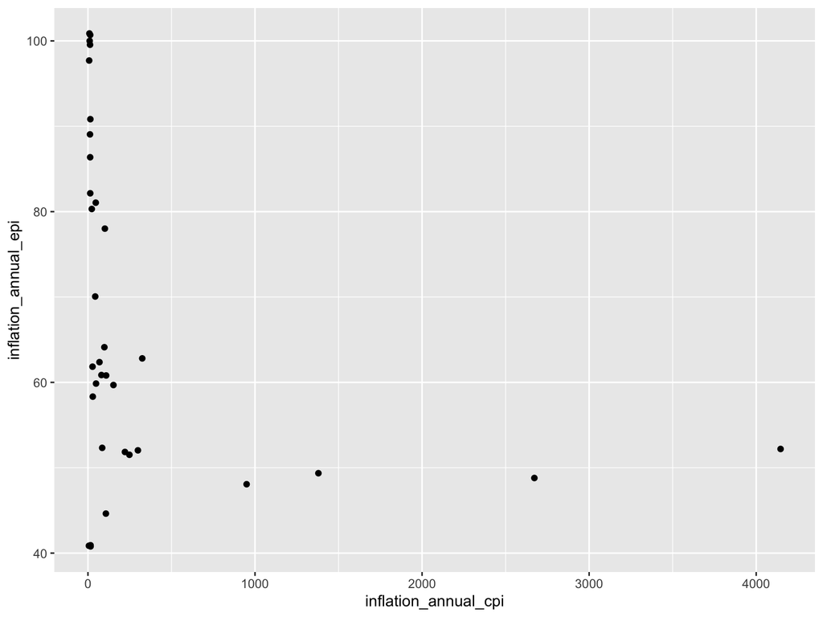

```r
ac_imf %>% filter(country=="Angola") %>% ggplot(aes(x=inflation_annual_cpi, y=inflation_annual_epi)) +
  geom_point()
```

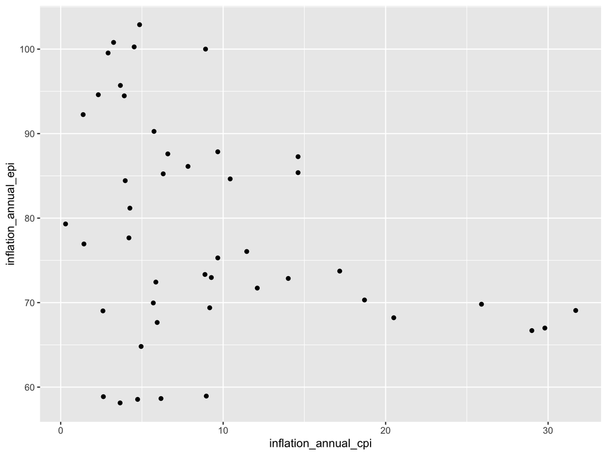

```r
ac_imf %>% filter(country=="Algeria") %>% ggplot(aes(x=inflation_annual_cpi, y=inflation_annual_epi)) +
  geom_point()
```

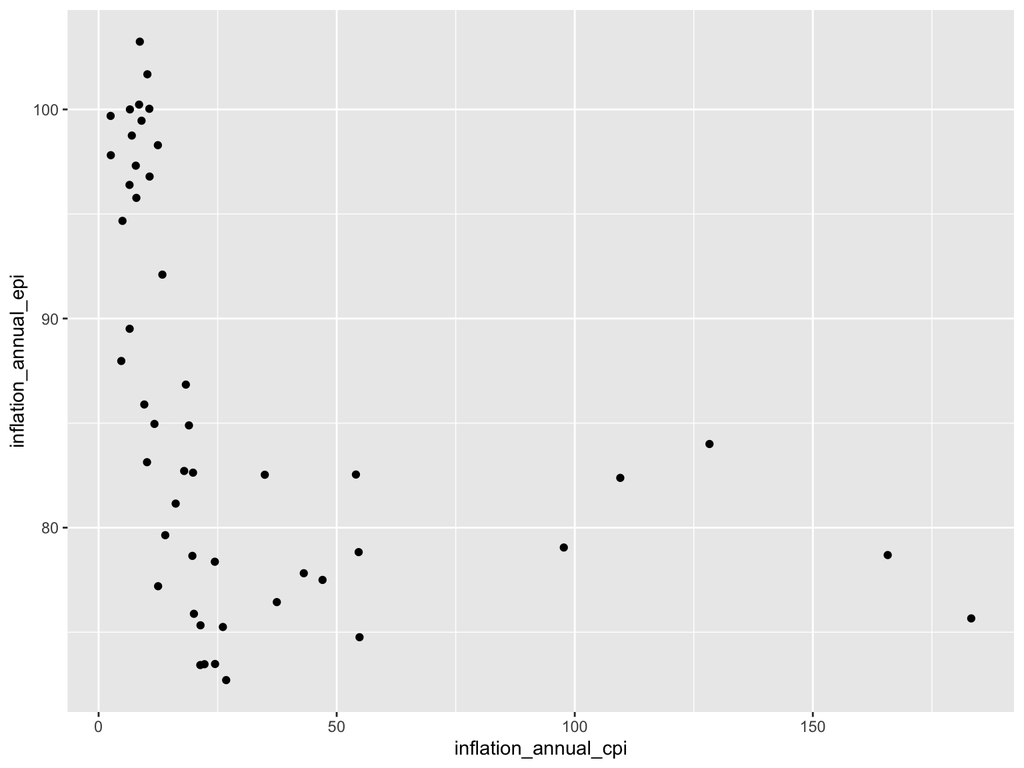

```r
ac_imf %>% filter(country=="Zambia") %>% ggplot(aes(x=inflation_annual_cpi, y=inflation_annual_epi)) +
  geom_point()
```

Next step is to do regression analysis for these 3 qualitative variables: inflation rate, export price index and exchange rate by using fixed effect model to be able to control country specific factors, that is, we assume each country has its own intercept value for the average level of inflation rate:

```r
regress2 <- lm(inflation_annual_cpi ~ exch_usd + inflation_annual_epi + factor(country) - 1, data = ac_imf)
summary(regress2)
```

```
##
## Call:
## lm(formula = inflation_annual_cpi ~ exch_usd + inflation_annual_epi +
##     factor(country) - 1, data = ac_imf)
##
## Residuals:
##      Min       1Q   Median       3Q      Max
##  -471303    -9008      -65     5184 21519207
##
## Coefficients:
##                                          Estimate Std. Error t value Pr(>|t|)
## exch_usd                                   -239.8      463.8  -0.517    0.605
## inflation_annual_epi                       1263.3     4863.2   0.260    0.795
## factor(country)Algeria                   -90484.6   401596.3  -0.225    0.822
## factor(country)Angola                    -76209.6   358525.6  -0.213    0.832
## factor(country)Central African Republic  -32019.0   510680.9  -0.063    0.950
## factor(country)Egypt                    -121363.0   486656.4  -0.249    0.803
## factor(country)Ivory Coast               -74175.8   481721.2  -0.154    0.878
## factor(country)Kenya                    -115914.7   497131.0  -0.233    0.816
## factor(country)Mauritius                -119942.6   493354.4  -0.243    0.808
## factor(country)Morocco                  -124570.4   502224.6  -0.248    0.804
## factor(country)Nigeria                   -90447.9   411409.4  -0.220    0.826
## factor(country)South Africa             -121922.8   489679.2  -0.249    0.803
## factor(country)Tunisia                  -119376.1   477516.0  -0.250    0.803
## factor(country)Zambia                   -108004.6   436156.3  -0.248    0.805
## factor(country)Zimbabwe                  344078.2   494528.8   0.696    0.487
##
## Residual standard error: 888000 on 600 degrees of freedom
## Multiple R-squared:  0.02146,    Adjusted R-squared:  -0.003
## F-statistic: 0.8774 on 15 and 600 DF,  p-value: 0.59
```

However, we do not get any significant coefficient estimate with a fixed-effect model.

Most of these countries became independent mid 1960s. To investigate the answer of this question we set about 20 years of control period of time. Thus, we run the regression on the data after 1945. Additionally, since there is a lot of fluctuation in inflation rate after the mid 1980s, we limited the data until 1985. By this way we set 20 years of control period of time and 20 years of treatment period of time, in terms of being independent:

```r
indep_sample <- ac %>% filter(year > "1945-01-01", year < "1985-01-01", inflation_annual_cpi !=0, exch_usd !=0)
indep_sample$independence <- as.numeric(indep_sample$independence)

regress3 <- lm(inflation_annual_cpi ~  exch_usd + independence + factor(country) -1, data = indep_sample)
summary(regress3)
```

```
##
## Call:
## lm(formula = inflation_annual_cpi ~ exch_usd + independence +
##     factor(country) - 1, data = indep_sample)
##
## Residuals:
##     Min      1Q  Median      3Q     Max
## -34.469  -5.446  -2.302   2.675  80.875
##
## Coefficients:
##                                          Estimate Std. Error t value Pr(>|t|)
## exch_usd                                 0.008525   0.012818   0.665  0.50638
## independence                             2.830262   1.495172   1.893  0.05909
## factor(country)Algeria                  10.480557   2.298454   4.560 6.82e-06
## factor(country)Angola                   17.596141   2.413009   7.292 1.65e-12
## factor(country)Central African Republic  3.684060   4.443214   0.829  0.40752
## factor(country)Egypt                     2.487469   2.466961   1.008  0.31392
## factor(country)Ivory Coast               5.457514   5.167074   1.056  0.29151
## factor(country)Kenya                     5.488594   2.217124   2.476  0.01372
## factor(country)Mauritius                 5.457505   2.127513   2.565  0.01068
## factor(country)Morocco                   7.590107   2.216455   3.424  0.00068
## factor(country)Nigeria                  16.123858   3.755331   4.294 2.21e-05
## factor(country)South Africa              3.683741   2.426885   1.518  0.12983
## factor(country)Tunisia                   6.666735   2.556768   2.607  0.00946
## factor(country)Zambia                    5.602859   2.073181   2.703  0.00717
## factor(country)Zimbabwe                  4.484259   2.089310   2.146  0.03245
##
## exch_usd
## independence                            .
## factor(country)Algeria                  ***
## factor(country)Angola                   ***
## factor(country)Central African Republic
## factor(country)Egypt
## factor(country)Ivory Coast
## factor(country)Kenya                    *
## factor(country)Mauritius                *
## factor(country)Morocco                  ***
## factor(country)Nigeria                  ***
## factor(country)South Africa
## factor(country)Tunisia                  **
## factor(country)Zambia                   **
## factor(country)Zimbabwe                 *
## ---
## Signif. codes:  0 '***' 0.001 '**' 0.01 '*' 0.05 '.' 0.1 ' ' 1
##
## Residual standard error: 11.93 on 399 degrees of freedom
## Multiple R-squared:  0.4031, Adjusted R-squared:  0.3807
## F-statistic: 17.96 on 15 and 399 DF,  p-value: < 2.2e-16
```

# 3 Data Visualizations

We create new data sets for this exploratory data analysis so as not to affect previous data sets.

```r
# Exploratory Data Sets
ac_eda <- ac %>%

  select(c(cc3, country, year, case, systemic_crisis, banking_crisis, currency_crises, inflation_crises, independence, domestic_debt_in_default, sovereign_external_debt_default, inflation_annual_cpi, exch_usd)) %>%

  mutate_at(
    vars(systemic_crisis, banking_crisis, currency_crises, inflation_crises, independence, domestic_debt_in_default, sovereign_external_debt_default),
    as.integer)

ed_orig <- data.frame(ac_eda)

ed <- ed_orig[ , -c(1:3) ]
```

We use data summaries, histograms, box and whisker plots, and scatter plots (outputs hidden) to ensure that there are no errors in the data and no outlying observations that we wish to remove from the data to be analyzed.

## 3.1 Graphical Display of a Correlation Matrix

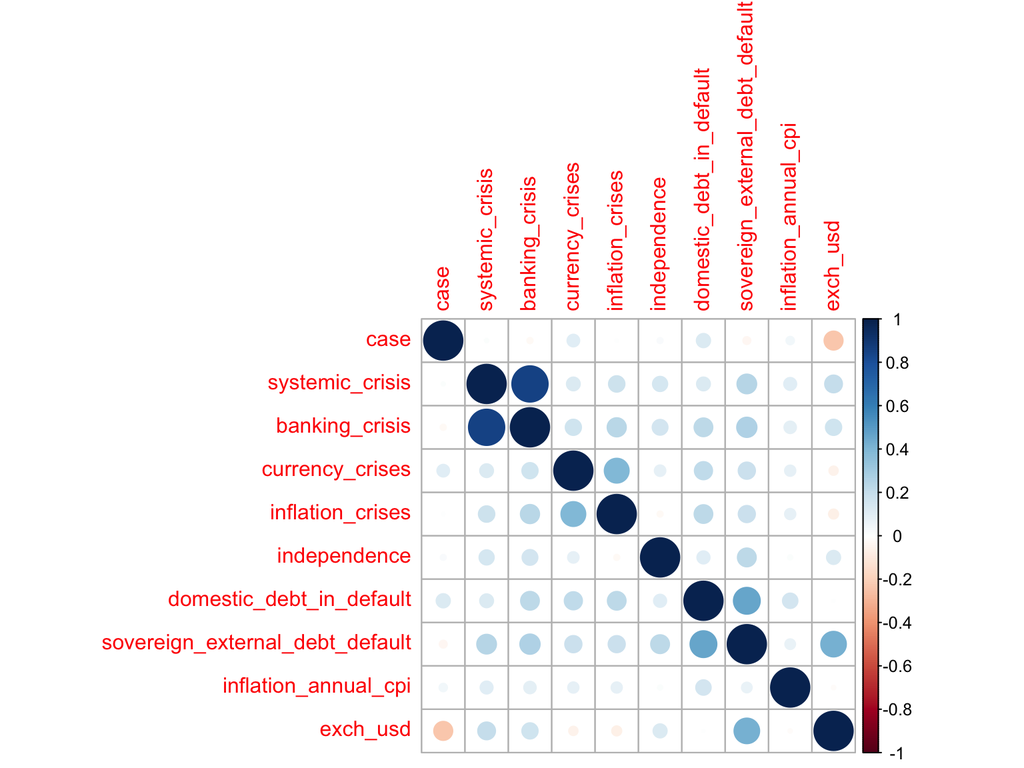

```r
library(corrplot)
correlations <- cor(ed)
corrplot(correlations, method="circle")
```

The strongest correlation is between systemic crises and banking crises, as expected. There are moderate correlation between sovereign external and domestic debt defaults (unsurprising), between USD exchange rate and sovereign external debt default (also unsurprising), and between inflation and currency crises (and again).

To increase confidence in our prediction of systemic crises, it may be useful to remove a predictor variable from each pair. We could remove sovereign external debt default or we could remove both domestic debt default and USD exchange rate. We can also remove currency crises since inflation crises are more strongly correlated with systemic crises than are currency crises, though both are weakly correlated with systemic crises.

In addition, banking crises are weakly correlated with both external and domestic debt defaults as well as inflation crises. Since banking crisis is strongly correlated with systemic crises, perhaps most of the information we would get from the default and crises data may already be contained in banking crisis. We reserve such model diagnostics and remedial measures for future analysis and continue with the data as is for the rest of the this analysis.

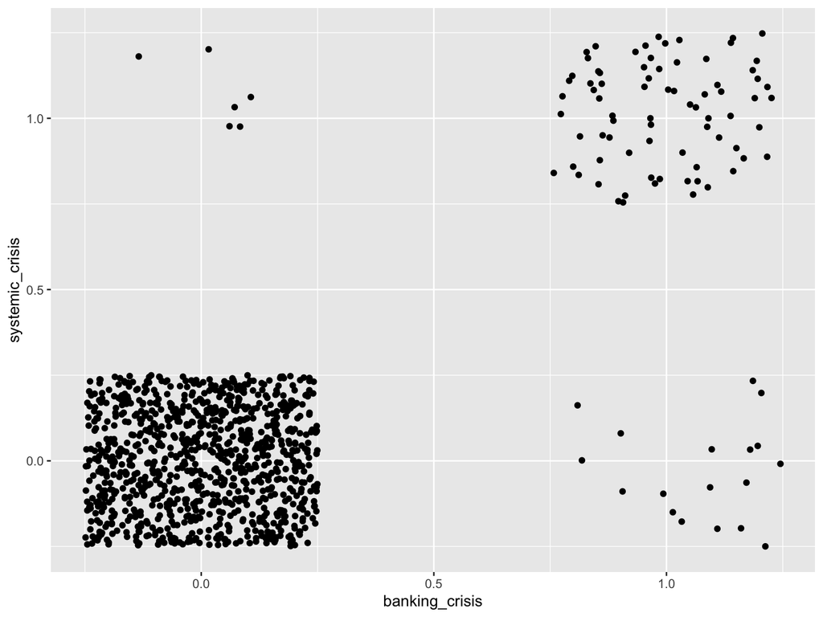

```r
plt <- ggplot(data = ed, mapping = aes(y = systemic_crisis))

plt +
  geom_jitter(mapping = aes(x = banking_crisis), width = .25, height = .25)
```

As expected, most of the data is not associated with crises, but when they are, banking crises and systemic crises usually occur together.

## 3.2 How does Systemic Crisis depend on time and independence?

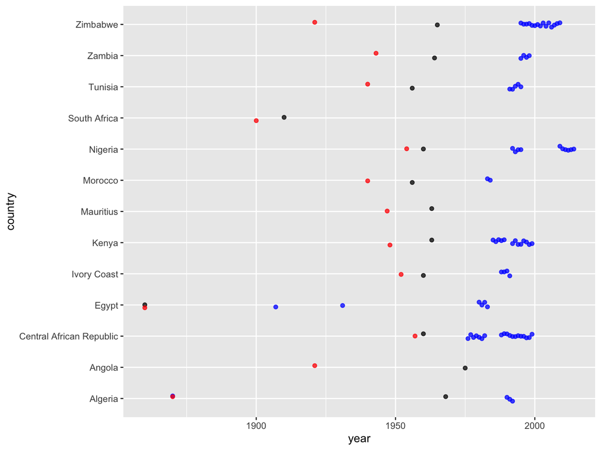

```r
year_table <- ac %>%
  group_by(country) %>%
  summarize(first_year = min(year), count = n() ) %>%
  arrange(first_year) %>%
  mutate(prop = count/sum(count))


indep_table <- ac %>%
  filter(independence == 1) %>%
  group_by(country) %>%
  summarize(indep_year = min(year), count = n() ) %>%
  arrange(indep_year) %>%
  mutate(prop = count/sum(count))


sys_crisis_table <- ac %>%
  filter(systemic_crisis == 1) %>%
  group_by(country) %>%
  summarize(earliest_sys_crisis = min(year), count = n() ) %>%
  arrange(earliest_sys_crisis) %>%
  mutate(prop = count/sum(count))


plt1 <- ggplot(data = filter(ac, systemic_crisis == TRUE))

plt1 +
  geom_jitter(mapping = aes(x = year, y = country),
             color = "blue", alpha = .75, width = .1, height = .1) +
  geom_jitter(data = indep_table,
             mapping = aes(x = indep_year, y = country),
             color = "black", alpha = .75, width = .1, height = .1) +
  geom_jitter(data = year_table,
             mapping = aes(x = first_year, y = country),
             color = "red", alpha = .75, width = .1, height = .1)
```

```r
# Add banking crises and other explanatory variables of interest
# Add custom legend
```

The leftmost red points indicate the first year of the data. The black points represent the first year of independence. The blue points indicate occurrences of systemic crises.

Most countries achieved independence by 1965. The four exceptions are Algeria (1968) and Angola (1975) on the later end and Egypt (1860) and South Africa (1910) on the earlier end. Consequently, Algeria and Angola have less filtered observations for analysis, while Egypt and South Africa alone would make up a large proportion of the data used for analysis. The four countries combined makeup almost about 40% of the data, so let’s use the proportion sizes to help us decide how to split the data for training/exploration and validation (query and test).

Only 82 total systemic crises in data, with the earliest occurring in Algeria in 1870 and in Egypt in 1907. Perhaps we should focus on analysis on the more recent period from 1976 and on, which also coincides with the time period when all countries had achieved independence, in order to train the model on data characterized by recent economic conditions under independence.

# 4 Preliminary model investigation

Let’s build a custom simple logistic regression so we can better understand what the built-in R functions are doing and better interpret their results.

## 4.1 Simple Logistic Regression (SLR) Model

The logistic response function:

```r
# Logistic response function
pi_i <- function(B0, B1, X) {
  return ( 1 / ( 1 + exp( - (B0 + B1 * X) ) ) )
}
```

The probability distribution for an observation is simply the probability mass function of a Bernoulli random variable. And since the Yi observations are assumed to be independent, their joint probability function is the likelihood.

```r
distr_i <- function(B0, B1, X, Y) {
  probs <- pi_i(B0, B1, X)
  return ( probs^Y * (1-probs)^(1-Y) )
}

likelihood <- function(B0, B1, X, Y) {
  return ( prod( distr_i(B0, B1, X, Y) ) )
}
```

However, it is numerically advantageous to find the maximum likelihood estimates by working with the logarithm of the joint probability function rather than the actual values which tend to be very close to zero and therefore prone to errors of computational precision. Therefore, the objective function to minimize is the log-likelihood:

```r
log_likelihood <- function(B0, B1, X, Y) {
  return ( sum( Y * log(pi_i(B0, B1, X))  + ( 1 - Y ) * log( 1 - pi_i(B0, B1, X) ) ) )
}
```

Create a helper function to use in the `optim()` function:

```r
ll_helper <- function(params) {
  return( -log_likelihood(params[1], params[2], X = X, Y = Y) )
  # Take the negative of the log-likelihood since we want to maximize this value but the optim() function minimizes by default.
}
```

Obtain point estimates of the coefficients of a simple logistic regression where the fitting is based on maximizing the log-likelihood of the data.

```r
X = ac$banking_crisis
Y = ac$systemic_crisis
params <- c(0, 0)
(best <- optim(par = params, fn = ll_helper))
```

```
## $par
## [1] -5.075807  6.516853
##
## $value
## [1] 82.37082
##
## $counts
## function gradient
##       75       NA
##
## $convergence
## [1] 0
##
## $message
## NULL
```

```r
probs <- pi_i(best$par[1], best$par[2], X)
cutoff <- mean(unique(probs)) # only two values
preds <- ifelse(probs > cutoff, TRUE, FALSE)
correct <- preds == Y

paste("Training Accuracy", mean(correct))
```

```
## [1] "Training Accuracy 0.977337110481586"
```

```r
paste("Sensitivity", mean(preds[Y==1] == Y[Y==1]))
```

```
## [1] "Sensitivity 0.926829268292683"
```

```r
paste("Specificity", mean(preds[Y==0] == Y[Y==0]))
```

```
## [1] "Specificity 0.98157625383828"
```

```r
paste("Correctly predicted",
  sum(preds & correct),
  "of",
  sum(Y),
  "crises"
)
```

```
## [1] "Correctly predicted 76 of 82 crises"
```

```r
paste("False positives",
  sum(preds & !(correct))
)
```

```
## [1] "False positives 18"
```

```r
paste("Cutoff value", cutoff)
```

```
## [1] "Cutoff value 0.407411962411237"
```

### 4.1.1 Compare to built-in function for Logistic Regression as a family of the Generalized Linear Model

```r
X = ac$banking_crisis
Y = ac$systemic_crisis
glm_df <- data.frame(Y, X)

glm_fit = glm(formula = Y ~ X, family = binomial(link = "logit"))

glm_probs <- predict(glm_fit, newdata = glm_df, type = "response")

glm_cutoff <- mean(unique(glm_probs))

glm_preds <- ifelse(glm_probs > glm_cutoff, TRUE, FALSE)

glm_correct <- glm_preds == Y

paste("Training Accuracy", mean(glm_correct))
```

```
## [1] "Training Accuracy 0.977337110481586"
```

```r
paste("Sensitivity", mean(preds[Y==1] == Y[Y==1]))
```

```
## [1] "Sensitivity 0.926829268292683"
```

```r
paste("Specificity", mean(preds[Y==0] == Y[Y==0]))
```

```
## [1] "Specificity 0.98157625383828"
```

```r
paste("Correctly predicted",
  sum(glm_preds & glm_correct),
  "of",
  sum(Y),
  "crises"
)
```

```
## [1] "Correctly predicted 76 of 82 crises"
```

```r
paste("False positives",
  sum(glm_preds & !(glm_correct))
)
```

```
## [1] "False positives 18"
```

```r
paste("Cutoff value", glm_cutoff)
```

```
## [1] "Cutoff value 0.407364127782024"
```

The default method “glm.fit” uses iteratively reweighted least squares (IWLS).

```r
(slr_ll <- log_likelihood(best$par[1], best$par[2], X, Y))
```

```
## [1] -82.37082
```

```r
(glm_ll <- log_likelihood(glm_fit$coefficients[1],
                          glm_fit$coefficients[2], X, Y) )
```

```
## [1] -82.3708
```

We end up with the same results from the custom and the built-in logistic regression functions, as desired.

The optimization procedure provides us with point estimates, but we have no measure of uncertainty for them: neither a standard deviation nor confidence intervals to determine whether or not they are different from 0 with any statistical certainty. The bootstrap method allows us to do so.

## 4.2 Bootstrap confidence intervals

Construct a bootstrap sample for the estimated coefficients of a simple logistic regression where the fitting is based on maximizing the log-likelihood.

```r
X = ac$banking_crisis
Y = ac$systemic_crisis
n <- length(Y)
M <- 1e3
b_params <- c(0, 0)
# fit_bstp <- vector(mode = "list", length = M)
b0 <- numeric(M)
b1 <- numeric(M)


max_ll_regression_helper_bstp <- function(b) {
  return( -log_likelihood(b[1], b[2], X = X_bstp, Y = Y_bstp) )
}

for (m in 1:M) {
  bstp <- sample(n, replace = TRUE)
  X_bstp <- X[bstp]
  Y_bstp <- Y[bstp]
  fit_bstp <- optim(b_params, max_ll_regression_helper_bstp)
  b0[m] <- fit_bstp$par[1]
  b1[m] <- fit_bstp$par[2]
}
```

### 4.2.1 Estimate the standard deviations of each of the coefficients.

```r
b1_summary <- summary(b1)
b1_samp_var <- sum( (b1 - b1_summary["Mean"])^2 ) / ( length(b1) - 1 )
(b1_std_dev <- sqrt(b1_samp_var))
```

```
## [1] 0.7217321
```

```r
sd(b1)
```

```
## [1] 0.7217321
```

### 4.2.2 Construct 95% confidence intervals for the coefficients and, based on those, determine whether or not we can reject a null hypothesis that each of them is equal to zero.

Let’s conduct a hypothesis test of significance.

```r
alpha <- .05
probs <- c(alpha/2, 1 - alpha/2)
```

Here are the results and a helpful visualization of the bootstrapped distribution of b1, the regression coefficient for banking crisis.

```r
( b1_empirical_bootstrap_CI <- quantile(b1, probs) )
```

```
##     2.5%    97.5%
## 5.743946 7.828133
```

```r
ifelse(b1_empirical_bootstrap_CI[1] < 0 & 0 < b1_empirical_bootstrap_CI[2], "Fail to reject null", "Reject null")
```

```
##          2.5%
## "Reject null"
```

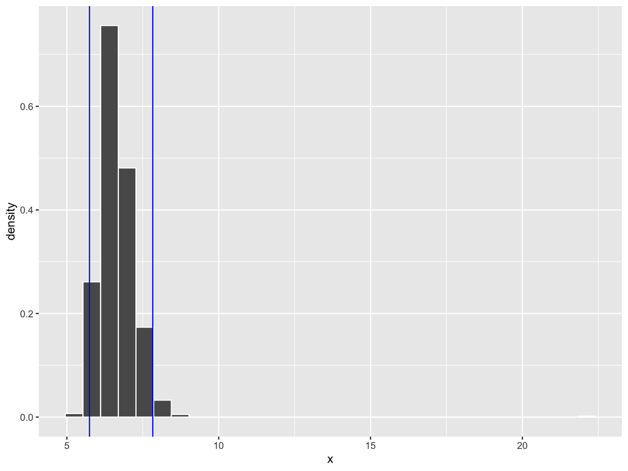

```r
ggplot(data.frame(x = b1)) +
  geom_histogram(aes(x = x, y = ..density..), color = "white") +
  geom_vline(xintercept = b1_empirical_bootstrap_CI, col = "blue")
```

Clearly, zero falls outside our bootstrapped confidence interval, indicating that B1 is significantly different than zero, and that banking crisis is a significant predictor of systemic crisis in our data.

## 4.3 Multiple Logistic Regression (MLR) Model

Now let’s build the multiple logistic regression model using all our predictor variables.

### 4.3.1 Optimization helper functions

Let’s create some functions to help us optimize on different values for the cutoff value that determines how probabilities are classified.

```r
# Let's optimize on a balanced sensitivity (true positives) and specificity (true negatives)
calc_balance <- function(cutoff) {
  mlr_preds <- ifelse(mlr_probs > cutoff, TRUE, FALSE)
  mlr_correct <- mlr_preds == resp
  training_accuracy <- mean(mlr_correct)
  sensitivity <- mean(mlr_preds[resp==1] == resp[resp==1])
  specificity <- mean(mlr_preds[resp==0] == resp[resp==0])
  return( abs(sensitivity - specificity) ) # which means minimizing the absolute difference between sensitivity and specificity
}

# We are also interested in maximizing the accuracy of predicting systemic crises, i.e. sensitivity.
calc_sensitivity <- function(cutoff) {
  mlr_preds <- ifelse(mlr_probs > cutoff, TRUE, FALSE)
  mlr_correct <- mlr_preds == resp
  sensitivity <- mean(mlr_preds[resp==1] == resp[resp==1])
  return(1-sensitivity) # which means minimizing the error rate given TRUE crises (1 - Sensitivity)
}
```

### 4.3.2 Multiple Logistic Regression of Systemic Crisis On All Predictors

```r
resp <- ac_eda$systemic_crisis

mlr_fit = glm(
  formula = systemic_crisis ~
    banking_crisis +
    currency_crises +
    inflation_crises +
    independence +
    domestic_debt_in_default +
    sovereign_external_debt_default +
    inflation_annual_cpi +
    exch_usd,
  data = ac_eda,
  family = binomial(link = "logit")
)
mlr_probs <- predict(mlr_fit, newdata = ac_eda, type = "response")

cutoff <- optim(glm_cutoff, calc_sensitivity, method = "Brent", lower = 0, upper = 1)$par

mlr_preds <- ifelse(mlr_probs > cutoff, TRUE, FALSE)

mlr_correct <- mlr_preds == resp

paste("Training Accuracy", mean(mlr_correct))
```

```
## [1] "Training Accuracy 0.977337110481586"
```

```r
paste("Sensitivity", mean(mlr_preds[resp==1] == resp[resp==1]))
```

```
## [1] "Sensitivity 0.926829268292683"
```

```r
paste("Specificity", mean(mlr_preds[resp==0] == resp[resp==0]))
```

```
## [1] "Specificity 0.98157625383828"
```

```r
paste("Correctly predicted",
  sum(mlr_preds & mlr_correct),
  "of",
  sum(resp),
  "crises"
)
```

```
## [1] "Correctly predicted 76 of 82 crises"
```

```r
paste("False positives",
  sum(mlr_preds & !(mlr_correct))
)
```

```
## [1] "False positives 18"
```

```r
paste("Cutoff value", cutoff)
```

```
## [1] "Cutoff value 0.236067992476449"
```

These are the same results we achieved from our simple logistic regression model with banking crisis as the sole predictor variable. For parsimony, it seems that we would do just as well to regress on banking crisis alone rather than regress on all other predictor variables.

So we were curious: What are the differences in effect on systemic crises between banking crisis at the other predictors?

Let’s look at the percent change that each predictor has on systemic crisis:

```r
signif(
  sort(
    exp(mlr_fit$coefficients) - 1,
    decreasing = TRUE),
  3)
```

```
##                  banking_crisis sovereign_external_debt_default
##                        8.97e+02                        3.79e+00
##                    independence                 currency_crises
##                        1.48e+00                        3.20e-01
##                        exch_usd            inflation_annual_cpi
##                        2.00e-03                        4.01e-05
##                inflation_crises        domestic_debt_in_default
##                       -4.77e-02                       -9.49e-01
##                     (Intercept)
##                       -9.98e-01
```

What happens if we wish to predict systemic crisis without the aid of data on banking crisis, as might be the case in a real financial crisis situation?

### 4.3.3 Multiple Logistic Regression of Systemic Crisis on All Predictor Variables Excluding Banking Crisis

```r
resp <- ac_eda$systemic_crisis

mlr_fit = glm(
  formula = systemic_crisis ~
    currency_crises +
    inflation_crises +
    independence +
    domestic_debt_in_default +
    sovereign_external_debt_default +
    inflation_annual_cpi +
    exch_usd,
  data = ac_eda,
  family = binomial(link = "logit")
)
mlr_probs <- predict(mlr_fit, newdata = ac_eda, type = "response")

cutoff <- optim(glm_cutoff, calc_balance, method = "Brent", lower = 0, upper = 1)$par

mlr_preds <- ifelse(mlr_probs > cutoff, TRUE, FALSE)

mlr_correct <- mlr_preds == resp

paste("Training Accuracy", mean(mlr_correct))
```

```
## [1] "Training Accuracy 0.785646836638338"
```

```r
paste("Sensitivity", mean(mlr_preds[resp==1] == resp[resp==1]))
```

```
## [1] "Sensitivity 0.768292682926829"
```

```r
paste("Specificity", mean(mlr_preds[resp==0] == resp[resp==0]))
```

```
## [1] "Specificity 0.787103377686796"
```

```r
paste("Correctly predicted",
  sum(mlr_preds & mlr_correct),
  "of",
  sum(resp),
  "crises"
)
```

```
## [1] "Correctly predicted 63 of 82 crises"
```

```r
paste("False positives",
  sum(mlr_preds & !(mlr_correct))
)
```

```
## [1] "False positives 208"
```

```r
paste("Cutoff value", cutoff)
```

```
## [1] "Cutoff value 0.0652772807347437"
```

Our model had between .75 and .8 training accuracy, sensitivity, and specificity. Though we were able to predict 63 out of 82 crises, we also had 208 false positives, and that magnitude is troubling. We have to think hard about how to balance the errors based on the costs of incorrect prediction, whether false positives or false negatives.

Let’s look at the effect that each predictor has on the probability of a systemic crisis, given the values of the other predictor variables are held fixed:

```r
signif(
  sort(
    exp(mlr_fit$coefficients) - 1,
    decreasing = TRUE),
  3)
```

```
##                    independence                inflation_crises
##                        1.76e+01                        2.79e+00
## sovereign_external_debt_default                 currency_crises
##                        1.05e+00                        1.78e-01
##                        exch_usd            inflation_annual_cpi
##                        3.20e-03                        7.07e-05
##        domestic_debt_in_default                     (Intercept)
##                       -1.34e-01                       -9.97e-01
```

But perhaps we only want to predict on future data, which means all the countries would be independent. Then independence is not an important predictor. We included it earlier as a control variable, but how does the regression differ when we only focus on data following independence, removing the need for a predictor variable for independence?

### 4.3.4 Multiple Logistic Regression of Systemic Crisis on All Predictor Variables Excluding Banking Crisis and Independence

```r
ac_eda <- filter(ac, independence == 1)

resp <- ac_eda$systemic_crisis

mlr_fit = glm(
  formula = systemic_crisis ~
    currency_crises +
    inflation_crises +
    domestic_debt_in_default +
    sovereign_external_debt_default +
    inflation_annual_cpi +
    exch_usd,
  data = ac_eda,
  family = binomial(link = "logit")
)
mlr_probs <- predict(mlr_fit, newdata = ac_eda, type = "response")

# Let's optimize on a balanced sensitivity and specificity this time
calc_balance <- function(cutoff) {
  mlr_preds <- ifelse(mlr_probs > cutoff, TRUE, FALSE)
  mlr_correct <- mlr_preds == resp
  training_accuracy <- mean(mlr_correct)
  sensitivity <- mean(mlr_preds[resp==1] == resp[resp==1])
  specificity <- mean(mlr_preds[resp==0] == resp[resp==0])
  return( abs(sensitivity - specificity) ) # which means minimizing the absolute difference between sensitivity and specificity
}

cutoff <- optim(glm_cutoff, calc_balance, method = "Brent", lower = 0, upper = 1)$par

mlr_preds <- ifelse(mlr_probs > cutoff, TRUE, FALSE)

mlr_correct <- mlr_preds == resp

paste("Training Accuracy", mean(mlr_correct))
```

```
## [1] "Training Accuracy 0.734793187347932"
```

```r
paste("Sensitivity", mean(mlr_preds[resp==1] == resp[resp==1]))
```

```
## [1] "Sensitivity 0.740740740740741"
```

```r
paste("Specificity", mean(mlr_preds[resp==0] == resp[resp==0]))
```

```
## [1] "Specificity 0.734143049932524"
```

```r
paste("Correctly predicted",
  sum(mlr_preds & mlr_correct),
  "of",
  sum(resp),
  "crises"
)
```

```
## [1] "Correctly predicted 60 of 81 crises"
```

```r
paste("False positives",
  sum(mlr_preds & !(mlr_correct))
)
```

```
## [1] "False positives 197"
```

```r
paste("Cutoff value", cutoff)
```

```
## [1] "Cutoff value 0.0759370538595521"
```

Now, our model had between .73 and .75 training accuracy, sensitivity, and specificity, so it has worse prediction accuracy without the predictor variable for independence included in the data and the model, which makes sense given that our previous scatterplot demonstrated that most systemic crises were associated with independence. Overall, the model still performs poorly in terms of prediction accuracy.

Let’s look at the percent change that each predictor has on the probability of a systemic crisis:

```r
signif(
  sort(
    exp(mlr_fit$coefficients) - 1,
    decreasing = TRUE),
  3)
```

```
##                inflation_crisesTRUE sovereign_external_debt_defaultTRUE
##                            2.94e+00                            1.02e+00
##                 currency_crisesTRUE                            exch_usd
##                            1.77e-01                            3.26e-03
##                inflation_annual_cpi        domestic_debt_in_defaultTRUE
##                            7.03e-05                           -1.37e-01
##                         (Intercept)
##                           -9.50e-01
```

# 5 Conclusions

Banking crisis was the most significant predictor of systemic crises. Dependency on export revenue made countries more likely to experience economic crises, in accordance with some economic theory.

However, our model made several assumptions. We distilled economic variables to logical values, which means we lose nuanced information. We did not take into account the time series, which only had year to year data and would not help with prediction on a a different time scale such as week or month.

For future analysis, we would like to investigate further economic variables with more granularity and perhaps model complexity such as interaction terms and diagnostic/remedial measures to help with model selection. We might also want to do further modeling and prediction with new samples from other countries.